# Homework 4: Logistic regression and judges

your name here

Due: Sunday, April 19, 2015

This assignment is based on an assignment created by [German Rodriguez](http://data.princeton.edu/wws509/sets/set3.html). Topics covered include:

- reading in tabular data
- ggplot2
- logistic regression

For this assignment you will be extending the analysis in this article:

Greene and Schaffer (1992) [“Leave to Appeal and Leave to Commence Judicial Review in Canada’s Refugee-Determination System: Is the Process Fair?”](http://yorkspace.library.yorku.ca/xmlui/handle/10315/7864) International Journal of Refugee Law, 4.1: 71-83.

Here’s how the authors describe the paper: “The purpose of this study is to determine whether refugees and other persons who are applying for leave to appeal a decision of the Convention Refugee Determination Division of the Canadian Immigration and Refugee Board, a decision of the Appeal Division of the Immigration and Refugee Board, or to commence an action for judicial review have a relatively equal chance to convince the Federal Court of Appeal of the merits of their applications.”"

The data and [documentation](http://socserv.mcmaster.ca/jfox/Books/Applied-Regression-2E/datasets/Greene.pdf) were made avaialble by John Fox. I have stored a copy of the data in Greene.txt in the subfolder data.

```r
library(dplyr)
data <- read.table("data/Greene.txt", header=TRUE)
data <- tbl_df(data)
```

Before doing anything else, just play with the data to get a sense of it.

1. The main outcome of interest is *decision* which records whether the judge granted an appeal or not. In what proprotion of cases did the judge grant an appeal.

```r
# convert decision to a number rather a factor
data$appeal_granted <- as.numeric(data$decision=="yes")
summarize(data, yes_rate = mean(appeal_granted))
```

```
## Source: local data frame [1 x 1]
##
##   yes_rate
## 1 0.296875
```

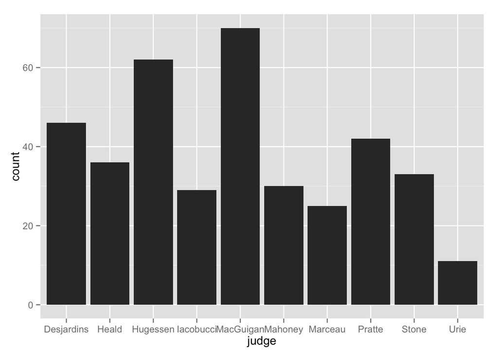

```r
library(ggplot2)
p <- ggplot(data, aes(judge))
p + geom_bar(stat="bin")
```

3. Now plot the rate at which the judges grant appeals.

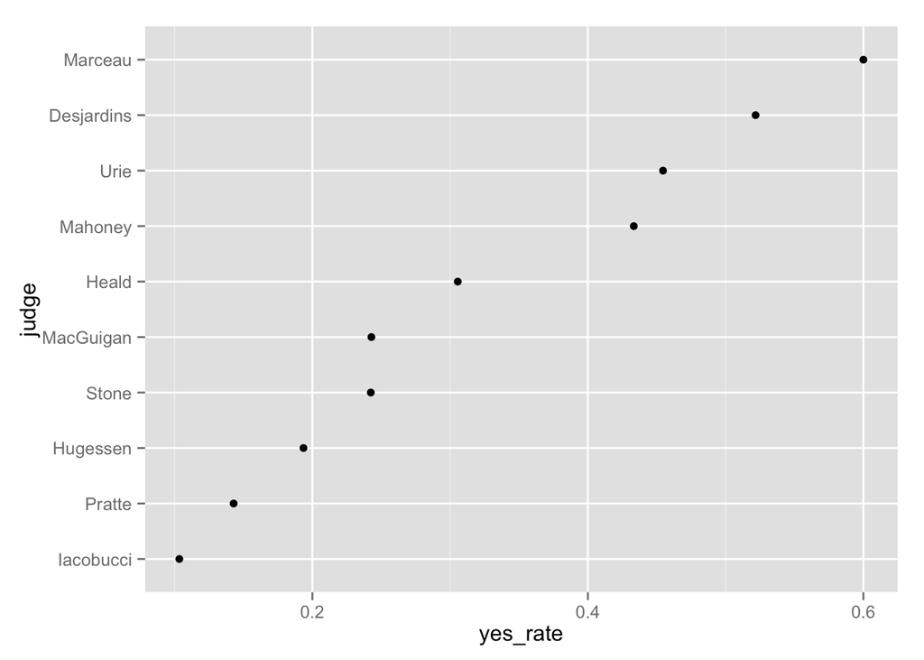

```r
data_to_plot <- group_by(data, judge) %>%
                  summarize(yes_rate = mean(appeal_granted)) %>%
                  arrange(desc(yes_rate))
data_to_plot$judge <- reorder(data_to_plot$judge, data_to_plot$yes_rate)
p <- ggplot(data_to_plot, aes(x = yes_rate, y = judge))
p + geom_point()
```

4. Now let’s try this with logistic regression because we are going to move to more complicated models. Fit a logistic regression predicting whetheran appeal will be granted using judge as a categorical predictor. Use Iacobucci as the reference judge to facilitate the comparisons that follow. For more on how to control the reference level of a factor, check out this post on StackOverflow: http://stackoverflow.com/questions/3872070/how-to-force-r-to-use-a-specified-factor-level-as-reference-in-a-regression

```r
data$judge <- relevel(data$judge, ref="Iacobucci")
fit <- glm(appeal_granted ~ judge, data = data, family = "binomial")
library(broom)
tidy(fit)
```

```
##               term   estimate std.error  statistic      p.value
## 1      (Intercept) -2.1594842 0.6097150 -3.5417930 0.0003974172
## 2  judgeDesjardins  2.2464956 0.6774021  3.3163401 0.0009120477
## 3       judgeHeald  1.3385037 0.7089861  1.8879124 0.0590377139
## 4    judgeHugessen  0.7323679 0.6892646  1.0625352 0.2879927768
## 5   judgeMacGuigan  1.0224057 0.6704056  1.5250554 0.1272452851
## 6     judgeMahoney  1.8912203 0.7123896  2.6547555 0.0079365903
## 7     judgeMarceau  2.5649493 0.7337704  3.4955748 0.0004730419
## 8      judgePratte  0.3677248 0.7524605  0.4886965 0.6250566009
## 9       judgeStone  1.0200500 0.7326337  1.3923056 0.1638298693
## 10       judgeUrie  1.9771627 0.8593131  2.3008641 0.0213993135
```

5. Using the results of the model calculate the predicted probability that Judge Marceau will grant an appeal.

```r
fit_tidy <- tidy(fit)
predicted_probability <- 1 / (1 + exp(-(fit_tidy[fit_tidy$term=="(Intercept)", "estimate"] + fit_tidy[fit_tidy$term=="judgeMarceau", "estimate"])))
print(paste("Predicted probability for Judge Marceau is:", predicted_probability))
```

```
## [1] "Predicted probability for Judge Marceau is: 0.599999999999999"
```

6. Perhaps the different judges have different types of cases. That might be why they seem to be making such different decisions. Fit a model treating judge as a factor plus the following predictors: (i) an indicator for whether the expert rater thought the case had merit, (ii) location indicators using ‘other’ as the reference category, (iii) a language dummy with French as omitted category. Note that as above you might have to relevel the factors to get this to work as you want.

```r
data$location <- relevel(data$location, ref="other")
data$language <- relevel(data$language, ref="French")
fit <- glm(appeal_granted ~ judge + rater + location + language, data = data, family = "binomial")
tidy(fit)
```

```
##                term   estimate std.error  statistic      p.value
## 1       (Intercept) -3.1099344 0.8821732 -3.5253103 4.229871e-04
## 2   judgeDesjardins  2.5118507 0.7134964  3.5204812 4.307645e-04
## 3        judgeHeald  1.3288574 0.7348309  1.8083852 7.054657e-02
## 4     judgeHugessen  1.2371875 0.7559655  1.6365660 1.017212e-01
## 5    judgeMacGuigan  1.3108339 0.7030106  1.8646005 6.223742e-02
## 6      judgeMahoney  1.7326906 0.7400300  2.3413788 1.921267e-02
## 7      judgeMarceau  3.4303647 0.8025491  4.2743364 1.917074e-05
## 8       judgePratte  0.6970888 0.7892341  0.8832471 3.771028e-01
## 9        judgeStone  0.9768491 0.7582761  1.2882500 1.976590e-01
## 10        judgeUrie  2.3313476 0.8969069  2.5993195 9.340879e-03
## 11         rateryes  1.4247201 0.2610852  5.4569166 4.844737e-08
## 12 locationMontreal -0.4276074 0.6158915 -0.6942903 4.875002e-01
## 13  locationToronto  0.1029737 0.3672029  0.2804273 7.791497e-01
## 14  languageEnglish  0.3268456 0.5580564  0.5856856 5.580868e-01
```

7. For a case that was ruled to have merit, that took place in Toronto, and that was in English, what is the predicted probability that Judge Marceau will grant the appeal?

```r
fit_tidy <- tidy(fit)
predictor_value <- fit_tidy[fit_tidy$term=="(Intercept)", "estimate"] +
  fit_tidy[fit_tidy$term=="rateryes", "estimate"] +
  fit_tidy[fit_tidy$term=="judgeMarceau", "estimate"] +
  fit_tidy[fit_tidy$term=="locationToronto", "estimate"] +
  fit_tidy[fit_tidy$term=="languageEnglish", "estimate"]
predicted_probability <- 1 / (1 + exp(-(predictor_value)))
print(paste("The predicted probability for this case is:", predicted_probability))
```

```
## [1] "The predicted probability for this case is: 0.897979154560357"
```